# dataFest 2015 Data Munging with R and dplyr

## filter()

```r
park %>% filter(`Issue Date` > "2013/09/01", `Issue Date` < "2014/6/30")
```

```
## Source: local data frame [80,761 x 20]
##
##    Plate ID Registration State Plate Type Issue Date Violation Code Vehicle Body Type
## 1   FXX9781                 NY        PAS 2014-02-20             20              SUBN
## 2   53902MB                 NY        COM 2013-10-24             14               VAN
## 3   FYM2426                 NY        PAS 2013-09-16             21               SDN
## 4   GPV3714                 NY        PAS 2014-06-10             71              SUBN
## 5    XBAV11                 NJ        PAS 2013-12-27             78               VAN
## 6   59305JY                 NY        COM 2013-09-18             38              DELV
## 7   2146518                 IN        PAS 2013-11-22             41               VAN
## 8   49138M2                 MD        PAS 2013-12-18             38              SUBN
## 9   GHD5283                 NY        PAS 2013-09-24             46              4DSD
## 10  GBR2885                 NY        PAS 2013-11-15             20              SUBN
## ..      ...                ...        ...        ...            ...               ...
## Variables not shown: Vehicle Make (chr), Vehicle Expiration Date (int), Violation
##   Precinct (int), Issuer Precinct (int), Issuer Code (int), Violation Time (chr),
##   Violation County (chr), Violation In Front Of Or Opposite (chr), House Number (chr),
##   Street Name (chr), Intersecting Street (chr), Days Parking In Effect (chr), Vehicle
##   Color (chr), Vehicle Year (int)
```

```r
park %>% filter(`Registration State` == "CA" | `Registration State` == "AZ")
```

```
## Source: local data frame [443 x 20]
##
##    Plate ID Registration State Plate Type Issue Date Violation Code Vehicle Body Type
## 1   4GXP803                 CA        PAS 2014-06-13             21              4DSD
## 2   6RXT702                 CA        PAS 2013-12-03             20              4DSD
## 3   AE32447                 AZ        PAS 2013-09-04             78              DELV
## 4    572WWB                 CA        PAS 2013-08-01             21              4DSD
## 5   AD56343                 AZ        PAS 2014-02-21             78              DELV
## 6   AD55598                 AZ        PAS 2013-12-20             14               VAN
## 7   6UXK262                 CA        PAS 2013-09-14             46              SUBN
## 8   5UIT291                 CA        PAS 2014-04-24             14              4DSD
## 9   AE85624                 AZ        PAS 2014-06-06             38               VAN
## 10  AE97488                 AZ        PAS 2013-11-20             14               VAN
## ..      ...                ...        ...        ...            ...               ...
## Variables not shown: Vehicle Make (chr), Vehicle Expiration Date (int), Violation
##   Precinct (int), Issuer Precinct (int), Issuer Code (int), Violation Time (chr),
##   Violation County (chr), Violation In Front Of Or Opposite (chr), House Number (chr),
##   Street Name (chr), Intersecting Street (chr), Days Parking In Effect (chr), Vehicle
##   Color (chr), Vehicle Year (int)
```

## slice()

```r
park %>% slice(3:8)
```

```
## Source: local data frame [6 x 20]
##
##   Plate ID Registration State Plate Type Issue Date Violation Code Vehicle Body Type
## 1  53902MB                 NY        COM 2013-10-24             14               VAN
## 2  FYM2426                 NY        PAS 2013-09-16             21               SDN
## 3  GPV3714                 NY        PAS 2014-06-10             71              SUBN
## 4   XBAV11                 NJ        PAS 2013-12-27             78               VAN
## 5  59305JY                 NY        COM 2013-09-18             38              DELV
## 6  2146518                 IN        PAS 2013-11-22             41               VAN
## Variables not shown: Vehicle Make (chr), Vehicle Expiration Date (int), Violation
##   Precinct (int), Issuer Precinct (int), Issuer Code (int), Violation Time (chr),
##   Violation County (chr), Violation In Front Of Or Opposite (chr), House Number (chr),
##   Street Name (chr), Intersecting Street (chr), Days Parking In Effect (chr), Vehicle
##   Color (chr), Vehicle Year (int)
```

```r
park %>% slice((n()-5):n())
```

```
## Source: local data frame [6 x 20]
##
##   Plate ID Registration State Plate Type Issue Date Violation Code Vehicle Body Type
## 1  69752MD                 NY        COM 2013-10-18             21               VAN
## 2  EUL4171                 NY        PAS 2013-10-18             21              4DSD
## 3  FYW4417                 NY        PAS 2014-05-20             46              SUBN
## 4  57224MA                 NY        COM 2013-09-17             82               VAN
## 5  PRU5820                 GA        PAS 2014-02-26             31              4DSD
## 6  93951JX                 NY        COM 2013-08-30             69               VAN
## Variables not shown: Vehicle Make (chr), Vehicle Expiration Date (int), Violation
##   Precinct (int), Issuer Precinct (int), Issuer Code (int), Violation Time (chr),
##   Violation County (chr), Violation In Front Of Or Opposite (chr), House Number (chr),
##   Street Name (chr), Intersecting Street (chr), Days Parking In Effect (chr), Vehicle
##   Color (chr), Vehicle Year (int)
```

## select()

```r
park %>% select(contains("street"))
```

```
## Source: local data frame [91,003 x 2]
##
##      Street Name Intersecting Street
## 1  ROCKAWAY BLVD
## 2      Austin St
## 3          8 AVE
## 4  GREENPORT AVE
## 5        E 40 ST
## 6     MADISON ST
## 7        62nd St
## 8         37 AVE
## 9  Manhattan Ave
## 10     E 21st St
## ..           ...                 ...
```

```r
park %>% select(`Plate ID`:`Plate Type`)
```

```
## Source: local data frame [91,003 x 3]
##
##    Plate ID Registration State Plate Type
## 1   FXX9781                 NY        PAS
## 2   FLZ6021                 NY        PAS
## 3   53902MB                 NY        COM
## 4   FYM2426                 NY        PAS
## 5   GPV3714                 NY        PAS
## 6    XBAV11                 NJ        PAS
## 7   59305JY                 NY        COM
## 8   2146518                 IN        PAS
## 9   49138M2                 MD        PAS
## 10  GHD5283                 NY        PAS
## ..      ...                ...        ...
```

```r
park %>% select(-(`Plate ID`:`Plate Type`))
```

```
## Source: local data frame [91,003 x 17]
##
##    Issue Date Violation Code Vehicle Body Type Vehicle Make Vehicle Expiration Date
## 1  2014-02-20             20              SUBN        HONDA                20140722
## 2  2013-08-12             37              4DSD        ME/BE                20150731
## 3  2013-10-24             14               VAN         FORD                20140809
## 4  2013-09-16             21               SDN        TOYOT                20140530
## 5  2014-06-10             71              SUBN         FORD                20151122
## 6  2013-12-27             78               VAN         FORD                       0
## 7  2013-09-18             38              DELV        FRUEH                20130930
## 8  2013-11-22             41               VAN        FRUEH                       0
## 9  2013-12-18             38              SUBN         FORD                20140188
## 10 2013-09-24             46              4DSD        NISSA                20150605
## ..        ...            ...               ...          ...                     ...
## Variables not shown: Violation Precinct (int), Issuer Precinct (int), Issuer Code (int),
##   Violation Time (chr), Violation County (chr), Violation In Front Of Or Opposite (chr),
##   House Number (chr), Street Name (chr), Intersecting Street (chr), Days Parking In
##   Effect (chr), Vehicle Color (chr), Vehicle Year (int)
```

## rename()

```r
park %>% rename(`Days Parking In Effect` = `Days Parking In Effect    `)
```

```
## Source: local data frame [91,003 x 20]
##
##    Plate ID Registration State Plate Type Issue Date Violation Code Vehicle Body Type
## 1   FXX9781                 NY        PAS 2014-02-20             20              SUBN
## 2   FLZ6021                 NY        PAS 2013-08-12             37              4DSD
## 3   53902MB                 NY        COM 2013-10-24             14               VAN
## 4   FYM2426                 NY        PAS 2013-09-16             21               SDN
## 5   GPV3714                 NY        PAS 2014-06-10             71              SUBN
## 6    XBAV11                 NJ        PAS 2013-12-27             78               VAN
## 7   59305JY                 NY        COM 2013-09-18             38              DELV
## 8   2146518                 IN        PAS 2013-11-22             41               VAN
## 9   49138M2                 MD        PAS 2013-12-18             38              SUBN
## 10  GHD5283                 NY        PAS 2013-09-24             46              4DSD
## ..      ...                ...        ...        ...            ...               ...
## Variables not shown: Vehicle Make (chr), Vehicle Expiration Date (int), Violation
##   Precinct (int), Issuer Precinct (int), Issuer Code (int), Violation Time (chr),
##   Violation County (chr), Violation In Front Of Or Opposite (chr), House Number (chr),
##   Street Name (chr), Intersecting Street (chr), Days Parking In Effect (chr), Vehicle
##   Color (chr), Vehicle Year (int)
```

## arrange()

```r
park %>% select(1:6) %>% arrange(`Registration State`, `Issue Date`)
```

```
## Source: local data frame [91,003 x 6]
##
##      Plate ID Registration State Plate Type Issue Date Violation Code Vehicle Body Type
## 1  BLANKPLATE                 99        999 2013-01-14             66              TRLR
## 2     67764JR                 99        COM 2013-07-17             14              DELV
## 3     3511235                 99        PAS 2013-07-18             18               VAN
## 4     1510956                 99        PAS 2013-07-18             19               VAN
## 5     35253MB                 99        COM 2013-07-18             46              DELV
## 6     27544PC                 99        999 2013-07-19             46               VAN
## 7     64869PA                 99        COM 2013-07-19             18              DELV
## 8     41591JM                 99        COM 2013-07-20             46               VAN
## 9  BLANKPLATE                 99        999 2013-07-20             74
## 10    30729JB                 99        COM 2013-07-22             19              DELV
## ..        ...                ...        ...        ...            ...               ...
```

## arrange() & desc()

```r
park %>% select(1:6) %>% arrange(`Registration State`,  desc(`Issue Date`))
```

```
## Source: local data frame [91,003 x 6]
##
##      Plate ID Registration State Plate Type Issue Date Violation Code Vehicle Body Type
## 1      TJE86H                 99        COM 2014-06-16             66              TRAI
## 2  BLANKPLATE                 99        999 2014-06-14             78
## 3  BLANKPLATE                 99        999 2014-06-12             20
## 4  BLANKPLATE                 99        999 2014-06-12             51               MCY
## 5  BLANKPLATE                 99        999 2014-06-12             20
## 6     B44845Y                 99        COM 2014-06-08             78               VAN
## 7     FWP5931                 99        PAS 2014-06-07             71               SDN
## 8  BLANKPLATE                 99        999 2014-06-06             74               MCY
## 9     20331TC                 99        TRC 2014-06-04             46              DELV
## 10 BLANKPLATE                 99        999 2014-06-04             38
## ..        ...                ...        ...        ...            ...               ...
```

## mutate()

```r
park %>% select(2:5) %>%
mutate(month = month(`Issue Date`),
       day = day(`Issue Date`),
       year = year(`Issue Date`),
       wday = wday(`Issue Date`, label=TRUE))
```

```
## Source: local data frame [91,003 x 8]
##
##    Registration State Plate Type Issue Date Violation Code month day year  wday
## 1                  NY        PAS 2014-02-20             20     2  20 2014 Thurs
## 2                  NY        PAS 2013-08-12             37     8  12 2013   Mon
## 3                  NY        COM 2013-10-24             14    10  24 2013 Thurs
## 4                  NY        PAS 2013-09-16             21     9  16 2013   Mon
## 5                  NY        PAS 2014-06-10             71     6  10 2014  Tues
## 6                  NJ        PAS 2013-12-27             78    12  27 2013   Fri
## 7                  NY        COM 2013-09-18             38     9  18 2013   Wed
## 8                  IN        PAS 2013-11-22             41    11  22 2013   Fri
## 9                  MD        PAS 2013-12-18             38    12  18 2013   Wed
## 10                 NY        PAS 2013-09-24             46     9  24 2013  Tues
## ..                ...        ...        ...            ...   ... ...  ...   ...
```

## transmute()

```r
park %>%
transmute(month = month(`Issue Date`),
          day = day(`Issue Date`),
          year = year(`Issue Date`),
          wday = wday(`Issue Date`, label=TRUE))
```

```
## Source: local data frame [91,003 x 4]
##
##    month day year  wday
## 1      2  20 2014 Thurs
## 2      8  12 2013   Mon
## 3     10  24 2013 Thurs
## 4      9  16 2013   Mon
## 5      6  10 2014  Tues
## 6     12  27 2013   Fri
## 7      9  18 2013   Wed
## 8     11  22 2013   Fri
## 9     12  18 2013   Wed
## 10     9  24 2013  Tues
## ..   ... ...  ...   ...
```

## distinct()

```r
park %>% distinct()
```

```
## Source: local data frame [91,003 x 20]
##
##    Plate ID Registration State Plate Type Issue Date Violation Code Vehicle Body Type
## 1   FXX9781                 NY        PAS 2014-02-20             20              SUBN
## 2   FLZ6021                 NY        PAS 2013-08-12             37              4DSD
## 3   53902MB                 NY        COM 2013-10-24             14               VAN
## 4   FYM2426                 NY        PAS 2013-09-16             21               SDN
## 5   GPV3714                 NY        PAS 2014-06-10             71              SUBN
## 6    XBAV11                 NJ        PAS 2013-12-27             78               VAN
## 7   59305JY                 NY        COM 2013-09-18             38              DELV
## 8   2146518                 IN        PAS 2013-11-22             41               VAN
## 9   49138M2                 MD        PAS 2013-12-18             38              SUBN
## 10  GHD5283                 NY        PAS 2013-09-24             46              4DSD
## ..      ...                ...        ...        ...            ...               ...
## Variables not shown: Vehicle Make (chr), Vehicle Expiration Date (int), Violation
##   Precinct (int), Issuer Precinct (int), Issuer Code (int), Violation Time (chr),
##   Violation County (chr), Violation In Front Of Or Opposite (chr), House Number (chr),
##   Street Name (chr), Intersecting Street (chr), Days Parking In Effect (chr), Vehicle
##   Color (chr), Vehicle Year (int)
```

## sample_n()

```r
park %>% select(1:6) %>% sample_n(10)
```

```
## Source: local data frame [10 x 6]
##
##    Plate ID Registration State Plate Type Issue Date Violation Code Vehicle Body Type
## 1   AZG739O                 NY        SRF 2013-07-30             21              4DSD
## 2     HUANG                 NY        RGL 2013-12-26             38              4DSD
## 3   CAV8344                 NC        PAS 2014-05-17             40              4DSD
## 4   57029JZ                 NY        COM 2014-02-04             46              DELV
## 5   20732PC                 NY        IRP 2014-03-13             19              DELV
## 6    AN790L                 NJ        PAS 2013-10-22             14              TRAC
## 7   GEK2525                 NY        OMS 2013-07-30             37              4DSD
## 8   DMJ8895                 NY        PAS 2014-01-30             21              SUBN
## 9   CTD5665                 NY        PAS 2014-02-11             38              SUBN
## 10  EHM9743                 NY        PAS 2014-01-18             14              4DSD
```

## sample_frac()

```r
park %>% select(1:6) %>% sample_frac(0.0001)
```

```
## Source: local data frame [9 x 6]
##
##   Plate ID Registration State Plate Type Issue Date Violation Code Vehicle Body Type
## 1  0L10BMC                 NJ        PAS 2014-04-22             31              SUBN
## 2  FZX9101                 NY        PAS 2013-10-30             71              SUBN
## 3  88711MB                 NY        COM 2014-05-16             45               VAN
## 4  EED6605                 NY        PAS 2014-04-01             83              SUBN
## 5   166TPE                 NY        ORG 2014-01-30             98               SDN
## 6   SVD10B                 NJ        PAS 2013-10-12             37              SUBN
## 7   AK120D                 NJ        PAS 2013-10-08             19              DELV
## 8  FWM4722                 NY        PAS 2013-10-16             20              4DSD
## 9    3H59B                 NY        OMT 2014-03-22             46              TAXI
```

## summarise()

```r
park %>% summarize(n(), min(`Issue Date`), max(`Issue Date`))
```

```
## Source: local data frame [1 x 3]
##
##     n() min(`Issue Date`) max(`Issue Date`)
## 1 91003        2000-02-20        2031-07-13
```

## group_by()

```r
group_by(park %>% select(1:6), `Registration State`)
```

```
## Source: local data frame [91,003 x 6]
## Groups: Registration State
##
##    Plate ID Registration State Plate Type Issue Date Violation Code Vehicle Body Type
## 1   FXX9781                 NY        PAS 2014-02-20             20              SUBN
## 2   FLZ6021                 NY        PAS 2013-08-12             37              4DSD
## 3   53902MB                 NY        COM 2013-10-24             14               VAN
## 4   FYM2426                 NY        PAS 2013-09-16             21               SDN
## 5   GPV3714                 NY        PAS 2014-06-10             71              SUBN
## 6    XBAV11                 NJ        PAS 2013-12-27             78               VAN
## 7   59305JY                 NY        COM 2013-09-18             38              DELV
## 8   2146518                 IN        PAS 2013-11-22             41               VAN
## 9   49138M2                 MD        PAS 2013-12-18             38              SUBN
## 10  GHD5283                 NY        PAS 2013-09-24             46              4DSD
## ..      ...                ...        ...        ...            ...               ...
```

## summarise() & group_by()

```r
park %>% select(1:6) %>%
group_by(`Registration State`) %>%
summarize(n(), min(`Issue Date`), max(`Issue Date`))
```

```
## Source: local data frame [62 x 4]
##
##    Registration State  n() min(`Issue Date`) max(`Issue Date`)
## 1                  99  348        2013-01-14        2014-06-16
## 2                  AB    3        2013-09-13        2014-06-19
## 3                  AK   13        2013-08-08        2014-06-09
## 4                  AL   52        2013-07-29        2014-06-24
## 5                  AR   22        2013-08-02        2014-06-02
## 6                  AZ  250        2013-07-22        2014-06-24
## 7                  BC    5        2013-12-18        2014-06-23
## 8                  CA  193        2013-07-24        2014-06-25
## 9                  CO   52        2013-07-30        2014-06-21
## 10                 CT 1388        2013-07-19        2014-06-25
## ..                ...  ...               ...               ...
```

```r
park %>% select(1:6) %>%
filter(`Plate Type` != 999) %>%
group_by(`Plate Type`, `Violation Code`) %>%
summarize(n = n(), n_states = n_distinct(`Registration State`))
```

```
## Source: local data frame [690 x 4]
## Groups: Plate Type
##
##    Plate Type Violation Code n n_states
## 1         AGC             19 1        1
## 2         AGR             17 1        1
## 3         AGR             71 1        1
## 4         AGR             82 1        1
## 5         APP             14 4        2
## 6         APP             19 2        2
## 7         APP             31 1        1
## 8         APP             38 2        1
## 9         APP             40 1        1
## 10        APP             46 4        2
## ..        ...            ... .      ...
```

## Putting it all together

Lets see if we can find out something about the distribution tickets through time.

```r
days = park %>% select(`Issue Date`) %>% group_by(`Issue Date`) %>% summarize(n = n())
days
```

```
## Source: local data frame [471 x 2]
##
##    Issue Date n
## 1  2000-02-20 1
## 2  2000-04-05 1
## 3  2000-11-06 1
## 4  2001-12-23 1
## 5  2003-12-24 1
## 6  2010-03-12 1
## 7  2010-09-11 1
## 8  2010-10-10 1
## 9  2010-10-13 1
## 10 2011-11-02 1
## ..        ... .
```

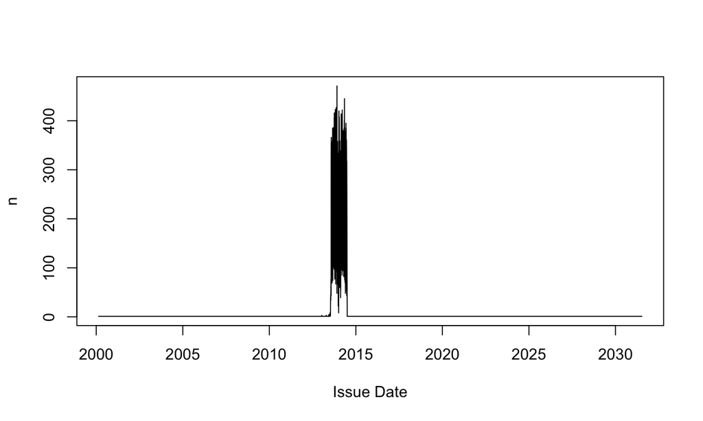

```r
plot(days,type='l')
```

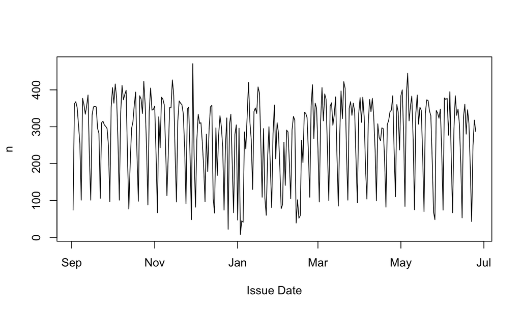

```r
days = days %>% filter(`Issue Date` > "2013/09/01", `Issue Date` < "2014/6/30")
plot(days,type='l')
```

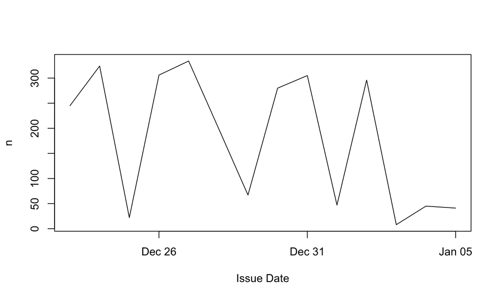

```r
plot(days %>% filter(`Issue Date` > "2013/12/22", `Issue Date` < "2014/1/5"),type='l')
```

## Exercise

Using the Parking Violation dataset,

- Construct a data frame containing Registration State and a issue date and time combined into a single DateTime column (try `paste` and `ymd_hm` from lubridate).
- Subset these data to include only datetimes between 09/01/2013 and 6/30/2014.
- Use these data to answer the following questions for both instate (NY registered cars) and out of state (non-NY registered cars):
  - What day of the week are you most likely to get a ticket?
  - What hour of the day are you most likely to get a ticket?
  - What hour and day of the week are you most likely to get a ticket?

## A Grammar of Data Manipulation (cont.)

Two table functions / verbs:

- `left_join` - Join matching rows from `b` to `a`.
- `right_join` - Join matching rows from `a` to `b`.
- `inner_join` - Join data. Retain only rows in both sets.
- `full_join` - Join data. Retain all values, all rows.
- `semi_join` - All rows in `a` that have a match in `b`.
- `anti_join` - All rows in `a` that do not have a match in `b`.

## Joining Data

```r
addr = data.frame(name = c("Alice","Bob",
                           "Carol","dave",
                           "Eve"),
                  email= c("alice@company.com",
                           "bob@company.com",
                           "carol@company.com",
                           "dave@company.com",
                           "eve@company.com"),
                  stringsAsFactors = FALSE)
```

```r
phone = data.frame(name = c("Bob","Carol",
                            "Eve","Eve",
                            "Frank"),
                   phone= c("919 555-1111",
                            "919 555-2222",
                            "919 555-3333",
                            "310 555-3333",
                            "919 555-4444"),
                   stringsAsFactors = FALSE)
```

```r
addr
```

```
##    name             email
## 1 Alice alice@company.com
## 2   Bob   bob@company.com
## 3 Carol carol@company.com
## 4  dave  dave@company.com
## 5   Eve   eve@company.com
```

```r
phone
```

```
##    name        phone
## 1   Bob 919 555-1111
## 2 Carol 919 555-2222
## 3   Eve 919 555-3333
## 4   Eve 310 555-3333
## 5 Frank 919 555-4444
```

## Outer Join

dplyr:

```r
full_join(addr, phone)
```

```
##    name             email        phone
## 1 Alice alice@company.com         <NA>
## 2   Bob   bob@company.com 919 555-1111
## 3 Carol carol@company.com 919 555-2222
## 4  dave  dave@company.com         <NA>
## 5   Eve   eve@company.com 919 555-3333
## 6   Eve   eve@company.com 310 555-3333
## 7 Frank              <NA> 919 555-4444
```

Base R:

```r
merge(addr, phone, all=TRUE)
```

```
##    name             email        phone
## 1 Alice alice@company.com         <NA>
## 2   Bob   bob@company.com 919 555-1111
## 3 Carol carol@company.com 919 555-2222
## 4  dave  dave@company.com         <NA>
## 5   Eve   eve@company.com 919 555-3333
## 6   Eve   eve@company.com 310 555-3333
## 7 Frank              <NA> 919 555-4444
```

## Inner Join

dplyr:

```r
inner_join(addr,phone)
```

```
##    name             email        phone
## 1   Bob   bob@company.com 919 555-1111
## 2 Carol carol@company.com 919 555-2222
## 3   Eve   eve@company.com 919 555-3333
## 4   Eve   eve@company.com 310 555-3333
```

Base R:

```r
merge(addr, phone, all=FALSE)
```

```
##    name             email        phone
## 1   Bob   bob@company.com 919 555-1111
## 2 Carol carol@company.com 919 555-2222
## 3   Eve   eve@company.com 919 555-3333
## 4   Eve   eve@company.com 310 555-3333
```

## Left Join

dplyr:

```r
left_join(addr,phone)
```

```
##    name             email        phone
## 1 Alice alice@company.com         <NA>
## 2   Bob   bob@company.com 919 555-1111
## 3 Carol carol@company.com 919 555-2222
## 4  dave  dave@company.com         <NA>
## 5   Eve   eve@company.com 919 555-3333
## 6   Eve   eve@company.com 310 555-3333
```

Base R:

```r
merge(addr, phone, all.x=TRUE)
```

```
##    name             email        phone
## 1 Alice alice@company.com         <NA>
## 2   Bob   bob@company.com 919 555-1111
## 3 Carol carol@company.com 919 555-2222
## 4  dave  dave@company.com         <NA>
## 5   Eve   eve@company.com 919 555-3333
## 6   Eve   eve@company.com 310 555-3333
```

## Right Join

dplyr:

```r
right_join(addr, phone)
```

```
##    name             email        phone
## 1   Bob   bob@company.com 919 555-1111
## 2 Carol carol@company.com 919 555-2222
## 3   Eve   eve@company.com 919 555-3333
## 4   Eve   eve@company.com 310 555-3333
## 5 Frank              <NA> 919 555-4444
```

Base R:

```r
merge(addr, phone, all.y=TRUE)
```

```
##    name             email        phone
## 1   Bob   bob@company.com 919 555-1111
## 2 Carol carol@company.com 919 555-2222
## 3   Eve   eve@company.com 919 555-3333
## 4   Eve   eve@company.com 310 555-3333
## 5 Frank              <NA> 919 555-4444
```

## Semi and Anti Joins

```r
semi_join(addr, phone)
```

```
##    name             email
## 1   Bob   bob@company.com
## 2 Carol carol@company.com
## 3   Eve   eve@company.com
```

```r
anti_join(addr, phone)
```

```
##    name             email
## 1  dave  dave@company.com
## 2 Alice alice@company.com
```

## tidyr

## Tidy Data

Hadley's Definition:

A dataset is messy or tidy depending on how rows, columns and tables are matched up with observations, variables and types.

In tidy data:

- Each variable forms a column.
- Each observation forms a row.
- Each type of observational unit forms a table.

Messy data is any other other arrangement of the data.

## Weather Data

```r
w = read_csv("weather.csv")
w
```

```
## Source: local data frame [22 x 35]
##
##         id year month element d 1  d 2  d 3 d 4  d 5 d 6 d 7 d 8 d 9 d 10 d 11 d 12 d 13
## 1  MX17004 2010     1    tmax  NA   NA   NA  NA   NA  NA  NA  NA  NA   NA   NA   NA   NA
## 2  MX17004 2010     1    tmin  NA   NA   NA  NA   NA  NA  NA  NA  NA   NA   NA   NA   NA
## 3  MX17004 2010     2    tmax  NA 27.3 24.1  NA   NA  NA  NA  NA  NA   NA 29.7   NA   NA
## 4  MX17004 2010     2    tmin  NA 14.4 14.4  NA   NA  NA  NA  NA  NA   NA 13.4   NA   NA
## 5  MX17004 2010     3    tmax  NA   NA   NA  NA 32.1  NA  NA  NA  NA 34.5   NA   NA   NA
## 6  MX17004 2010     3    tmin  NA   NA   NA  NA 14.2  NA  NA  NA  NA 16.8   NA   NA   NA
## 7  MX17004 2010     4    tmax  NA   NA   NA  NA   NA  NA  NA  NA  NA   NA   NA   NA   NA
## 8  MX17004 2010     4    tmin  NA   NA   NA  NA   NA  NA  NA  NA  NA   NA   NA   NA   NA
## 9  MX17004 2010     5    tmax  NA   NA   NA  NA   NA  NA  NA  NA  NA   NA   NA   NA   NA
## 10 MX17004 2010     5    tmin  NA   NA   NA  NA   NA  NA  NA  NA  NA   NA   NA   NA   NA
## ..     ...  ...   ...     ... ...  ...  ... ...  ... ... ... ... ...  ...  ...  ...  ...
## Variables not shown: d 14 (dbl), d 15 (dbl), d 16 (dbl), d 17 (dbl), d 18 (lgl), d 19
##   (lgl), d 20 (lgl), d 21 (lgl), d 22 (lgl), d 23 (dbl), d 24 (lgl), d 25 (dbl), d 26
##   (dbl), d 27 (dbl), d 28 (dbl), d 29 (dbl), d 30 (dbl), d 31 (dbl)
```

## From Wide to Long

```r
w %>% gather(day, value, `d 1`:`d 31`, na.rm = TRUE)
```

```
## Source: local data frame [66 x 6]
##
##         id year month element day value
## 1  MX17004 2010    12    tmax d 1  29.9
## 2  MX17004 2010    12    tmin d 1  13.8
## 3  MX17004 2010     2    tmax d 2  27.3
## 4  MX17004 2010     2    tmin d 2  14.4
## 5  MX17004 2010    11    tmax d 2  31.3
## 6  MX17004 2010    11    tmin d 2  16.3
## 7  MX17004 2010     2    tmax d 3  24.1
## 8  MX17004 2010     2    tmin d 3  14.4
## 9  MX17004 2010     7    tmax d 3  28.6
## 10 MX17004 2010     7    tmin d 3  17.5
## ..     ...  ...   ...     ... ...   ...
```

```r
w %>% gather(day, value, -(id:element), na.rm = TRUE)
```

```
## Source: local data frame [66 x 6]
##
##         id year month element day value
## 1  MX17004 2010    12    tmax d 1  29.9
## 2  MX17004 2010    12    tmin d 1  13.8
## 3  MX17004 2010     2    tmax d 2  27.3
## 4  MX17004 2010     2    tmin d 2  14.4
## 5  MX17004 2010    11    tmax d 2  31.3
## 6  MX17004 2010    11    tmin d 2  16.3
## 7  MX17004 2010     2    tmax d 3  24.1
## 8  MX17004 2010     2    tmin d 3  14.4
## 9  MX17004 2010     7    tmax d 3  28.6
## 10 MX17004 2010     7    tmin d 3  17.5
## ..     ...  ...   ...     ... ...   ...
```

## Data cleaning

```r
w %>%
gather(day, value, -(id:element), na.rm = TRUE) %>%
mutate(date = as.Date(paste(year, month, extract_numeric(day), sep="-"))) %>%
select(id, date, element, value) %>%
arrange(id, date, desc(element))
```

```
## Source: local data frame [66 x 4]
##
##         id       date element value
## 1  MX17004 2010-01-30    tmin  14.5
## 2  MX17004 2010-01-30    tmax  27.8
## 3  MX17004 2010-02-02    tmin  14.4
## 4  MX17004 2010-02-02    tmax  27.3
## 5  MX17004 2010-02-03    tmin  14.4
## 6  MX17004 2010-02-03    tmax  24.1
## 7  MX17004 2010-02-11    tmin  13.4
## 8  MX17004 2010-02-11    tmax  29.7
## 9  MX17004 2010-02-23    tmin  10.7
## 10 MX17004 2010-02-23    tmax  29.9
## ..     ...        ...     ...   ...
```

## Finishing up

```r
w %>%
gather(day, value, -(id:element), na.rm = TRUE) %>%
mutate(date = as.Date(paste(year, month, extract_numeric(day), sep="-"))) %>%
select(id, date, element, value) %>%
arrange(id, date, desc(element)) %>%
spread(element, value)
```

```
## Source: local data frame [33 x 4]
##
##         id       date tmax tmin
## 1  MX17004 2010-01-30 27.8 14.5
## 2  MX17004 2010-02-02 27.3 14.4
## 3  MX17004 2010-02-03 24.1 14.4
## 4  MX17004 2010-02-11 29.7 13.4
## 5  MX17004 2010-02-23 29.9 10.7
## 6  MX17004 2010-03-05 32.1 14.2
## 7  MX17004 2010-03-10 34.5 16.8
## 8  MX17004 2010-03-16 31.1 17.6
## 9  MX17004 2010-04-27 36.3 16.7
## 10 MX17004 2010-05-27 33.2 18.2
## ..     ...        ...  ...  ...
```

## Exercise

We've also provided a data set from the billboard music charts (`billboard.csv`), using what we've covered so far try to tidy this data into a more useful and usable structure.

```r
bb = read_csv("billboard.csv")
```

## Acknowledgments

## Acknowledgments

Above materials are derived in part from the following sources:

- [RStudio Data Wrangling Cheat Sheet](http://www.rstudio.com/wp-content/uploads/2015/02/data-wrangling-cheatsheet.pdf)
- Package Vigenettes - [dplyr](http://cran.r-project.org/web/packages/dplyr/vignettes/introduction.html), [tidyr](http://cran.r-project.org/web/packages/tidyr/vignettes/tidy-data.html)
- [UseR 2014 - dplyr Tutorial](https://www.dropbox.com/sh/i8qnluwmuieicxc/AAAgt9tIKoIm7WZKIyK25lh6a)